# ESE527-practice2

Can Song

2022/2/25

## Solution of Problem 2:

First we install and read three packages related to outlier detection mentioned in Practice 2.

```r
library(OutlierDetection)
library(OutliersO3)
library(outliers)
```

The data set we use in our project is called "Credit Card Approval". Here we only extract six features and the first 10,000 rows of the first table "application_record.csv" from the original data set.

The features are: gender, number of children, annual income, education level, marital status and ways of living. We choose to ignore the ID of clients and replace this column with indices.

In the following part we show the first six rows of the new table "application1.csv".

```r
library(readr)
library(knitr)
options(encoding = "UTF-8")

application1 <- read_csv("E:/MS-WUSTL/SP2022/ESE 527/practice2/application1.csv", show_col_types = FALSE)
head(application1)
```

| INDEX | CODE_GENDER | CNT_CHILDREN | AMT_INCOME_TOTAL | NAME_EDUCATION_TYPE | NAME_FAMILY_STATUS | NAME_HOUSING_TYPE |
| --- | --- | --- | --- | --- | --- | --- |
| 1 | M | 0 | 427500 | Higher education | Civil marriage | Rented apartment |
| 2 | M | 0 | 427500 | Higher education | Civil marriage | Rented apartment |
| 3 | M | 0 | 112500 | Secondary / secondary special | Married | House / apartment |
| 4 | F | 0 | 270000 | Secondary / secondary special | Single / not married | House / apartment |
| 5 | F | 0 | 270000 | Secondary / secondary special | Single / not married | House / apartment |
| 6 | F | 0 | 270000 | Secondary / secondary special | Single / not married | House / apartment |

Considering that some of the features in the table "application1.csv" are demonstrated by words instead of numbers, we change these columns with scalar numbers.

The features that need changes are: gender, education level, marital status and ways of living.

First we find out how many different values each feature has.

```r
gender_val<-unique(application1[,2])
education_val<-unique(application1[,5])
marital_val<-unique(application1[,6])
housing_val<-unique(application1[,7])

library("plyr")
list1<-list()
list1[[1]]<-data.frame(t(gender_val))
list1[[2]]<-data.frame(t(education_val))
list1[[3]]<-data.frame(t(marital_val))
list1[[4]]<-data.frame(t(housing_val))
values<-rbind.fill(list1)
t(values)
```

```
##    [,1] [,2]                            [,3]
## X1 "M"  "Higher education"              "Civil marriage"
## X2 "F"  "Secondary / secondary special" "Married"
## X3 NA   "Incomplete higher"             "Single / not married"
## X4 NA   "Lower secondary"               "Separated"
## X5 NA   "Academic degree"               "Widow"
## X6 NA   NA                              NA
##    [,4]
## X1 "Rented apartment"
## X2 "House / apartment"
## X3 "Municipal apartment"
## X4 "With parents"
## X5 "Co-op apartment"
## X6 "Office apartment"
```

Then we substitute these words with numbers.

For the education level, we set 1 for "Academic degree", 2 for "Lower secondary", 3 for "Incomplete higher", 4 for "Secondary / secondary special" and 5 for "Higher education".

For the marital status, we set 1 for "Civil marriage", 2 for "Married", 3 for "Single / not married", 4 for "Separated" and 5 for "Widow".

For the ways of living, we set 1 for "Rented apartment", 2 for "House / apartment", 3 for "Municipal apartment", 4 for "With parents", 5 for "Co-op apartment" and 6 for "Office apartment".

```r
a<-sub("M", "0", application1$CODE_GENDER)
b<-sub("F", "1", a)
gender<-as.numeric(b)

a<-sub("Academic degree", "1", application1$NAME_EDUCATION_TYPE)
b<-sub("Lower secondary", "2", a)
c<-sub("Incomplete higher", "3", b)
d<-sub("Secondary / secondary special", "4", c)
e<-sub("Higher education", "5", d)
education<-as.numeric(e)

a<-sub("Civil marriage", "1", application1$NAME_FAMILY_STATUS)
b<-sub("Married", "2", a)
c<-sub("Single / not married", "3", b)
d<-sub("Separated", "4", c)
e<-sub("Widow", "5", d)
marital<-as.numeric(e)

a<-sub("Rented apartment", "1", application1$NAME_HOUSING_TYPE)
b<-sub("House / apartment", "2", a)
c<-sub("Municipal apartment", "3", b)
d<-sub("With parents", "4", c)
e<-sub("Co-op apartment", "5", d)
f<-sub("Office apartment", "6", e)
housing<-as.numeric(f)

index<-application1$INDEX
num_child<-application1$CNT_CHILDREN
ann_income<-application1$AMT_INCOME_TOTAL

newdata<-data.frame(index, gender, num_child, ann_income, education, marital, housing)
head(newdata)
```

|  | index | gender | num_child | ann_income | education | marital | housing |
| --- | --- | --- | --- | --- | --- | --- | --- |
| 1 | 1 | 0 | 0 | 427500 | 5 | 1 | 1 |
| 2 | 2 | 0 | 0 | 427500 | 5 | 1 | 1 |
| 3 | 3 | 0 | 0 | 112500 | 4 | 2 | 2 |
| 4 | 4 | 1 | 0 | 270000 | 4 | 3 | 2 |
| 5 | 5 | 1 | 0 | 270000 | 4 | 3 | 2 |
| 6 | 6 | 1 | 0 | 270000 | 4 | 3 | 2 |

Then we construct the summary of "application1.csv" with the summary function.

```r
summary(newdata)
```

```
##      index           gender         num_child        ann_income
##  Min.   :    1   Min.   :0.0000   Min.   :0.0000   Min.   :  33300
##  1st Qu.: 2501   1st Qu.:0.0000   1st Qu.:0.0000   1st Qu.: 121500
##  Median : 5000   Median :1.0000   Median :0.0000   Median : 171000
##  Mean   : 5000   Mean   :0.6682   Mean   :0.4053   Mean   : 192739
##  3rd Qu.: 7500   3rd Qu.:1.0000   3rd Qu.:1.0000   3rd Qu.: 225000
##  Max.   :10000   Max.   :1.0000   Max.   :4.0000   Max.   :1350000
##    education        marital         housing
##  Min.   :1.000   Min.   :1.000   Min.   :1.000
##  1st Qu.:4.000   1st Qu.:2.000   1st Qu.:2.000
##  Median :4.000   Median :2.000   Median :2.000
##  Mean   :4.184   Mean   :2.296   Mean   :2.133
##  3rd Qu.:5.000   3rd Qu.:2.000   3rd Qu.:2.000
##  Max.   :5.000   Max.   :5.000   Max.   :6.000
```

The histograms of all feature are hence drawn below.

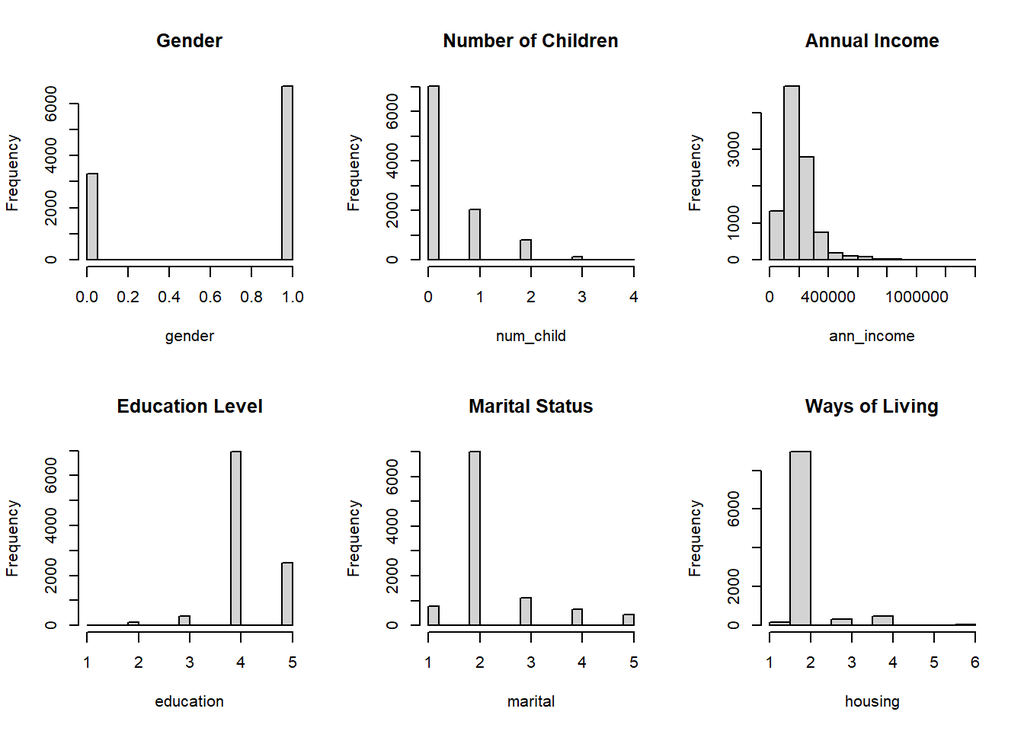

```r
par(mfrow=c(2, 3))
hist(gender, main="Gender")
hist(num_child, main="Number of Children")
hist(ann_income, main="Annual Income")
hist(education, main="Education Level")
hist(marital, main="Marital Status")
hist(housing, main="Ways of Living")
```

```r
par()
```

[output not shown]

[output cut: 160 more lines]

[output not shown]

We coud also get the matrix of scatterplots related to the "application1.csv", which is shown below.

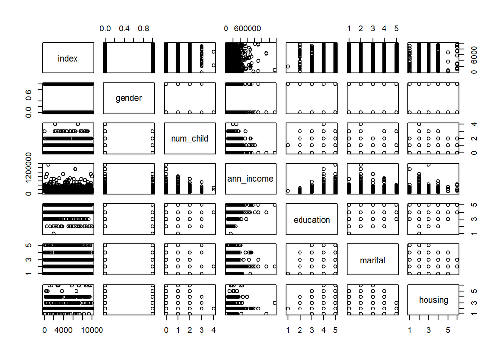

```r
pairs(newdata)
```

### 1.-Statistical Tests based Approaches:

#### a) Dixon test (small sample size)

Here we test the first 30 rows of the feature "Annual Income".

```r
x<-newdata[1:30,4]
dixon.test(x,type=0,opposite=TRUE)
```

```
##
##  Dixon test for outliers
##
## data:  x
## Q = 0, p-value < 2.2e-16
## alternative hypothesis: lowest value 112500 is an outlier
```

Since the data set we use in our project is really large, it is obvious that it would not fit the Dixon test which is fro small sample size. We would not use this method for our data set.

#### b) Normalscore (Deviation with respect to the mean)

```r
x<-newdata[,2:7]
#scores(X,type="z",prob=0.95)
#Displaying first 10 scores
scores(x,type="z",prob=0.95)[1:10,]
```

|  | gender | num_child | ann_income | education | marital | housing |
| --- | --- | --- | --- | --- | --- | --- |
| 1 | FALSE | FALSE | TRUE | FALSE | FALSE | TRUE |
| 2 | FALSE | FALSE | TRUE | FALSE | FALSE | TRUE |
| 3 | FALSE | FALSE | FALSE | FALSE | FALSE | FALSE |
| 4 | FALSE | FALSE | FALSE | FALSE | FALSE | FALSE |
| 5 | FALSE | FALSE | FALSE | FALSE | FALSE | FALSE |
| 6 | FALSE | FALSE | FALSE | FALSE | FALSE | FALSE |
| 7 | FALSE | FALSE | FALSE | FALSE | FALSE | FALSE |
| 8 | FALSE | FALSE | FALSE | FALSE | TRUE | FALSE |
| 9 | FALSE | FALSE | FALSE | FALSE | TRUE | FALSE |
| 10 | FALSE | FALSE | FALSE | FALSE | TRUE | FALSE |

In the first 10 rows, the outliers are the first two values of ann_income, the last three values of marital ans the first two values of housing.

#### c) Median Absolute Deviation (Deviation with respect to the median)

```r
x<-newdata[,2:7]
#scores(X,type="mad",prob=0.95)
#Displaying first 10 scores
scores(x,type="mad",prob=0.95)[1:10,]
```

|  | gender | num_child | ann_income | education | marital | housing |
| --- | --- | --- | --- | --- | --- | --- |
| 1 | TRUE | NA | TRUE | TRUE | TRUE | TRUE |
| 2 | TRUE | NA | TRUE | TRUE | TRUE | TRUE |
| 3 | TRUE | NA | FALSE | NA | NA | NA |
| 4 | NA | NA | FALSE | NA | TRUE | NA |
| 5 | NA | NA | FALSE | NA | TRUE | NA |
| 6 | NA | NA | FALSE | NA | TRUE | NA |
| 7 | NA | NA | FALSE | NA | TRUE | NA |
| 8 | NA | NA | FALSE | TRUE | TRUE | NA |
| 9 | NA | NA | FALSE | TRUE | TRUE | NA |
| 10 | NA | NA | FALSE | TRUE | TRUE | NA |

Since there are null values in the test results, we could conculde that the MAD method is not suitable for our data set of credit crad approval.

#### d) Interquantile range score

```r
x<-newdata[,2:7]
#scores(X,type="iqr",lim=1)
#Displaying first 10 scores
scores(x,type="iqr",lim=1)[1:10,]
```

|  | gender | num_child | ann_income | education | marital | housing |
| --- | --- | --- | --- | --- | --- | --- |
| 1 | FALSE | FALSE | TRUE | FALSE | TRUE | TRUE |
| 2 | FALSE | FALSE | TRUE | FALSE | TRUE | TRUE |
| 3 | FALSE | FALSE | FALSE | FALSE | FALSE | FALSE |
| 4 | FALSE | FALSE | FALSE | FALSE | TRUE | FALSE |
| 5 | FALSE | FALSE | FALSE | FALSE | TRUE | FALSE |
| 6 | FALSE | FALSE | FALSE | FALSE | TRUE | FALSE |
| 7 | FALSE | FALSE | FALSE | FALSE | TRUE | FALSE |
| 8 | FALSE | FALSE | FALSE | FALSE | TRUE | FALSE |
| 9 | FALSE | FALSE | FALSE | FALSE | TRUE | FALSE |
| 10 | FALSE | FALSE | FALSE | FALSE | TRUE | FALSE |

### 2. Depth-based Approach:

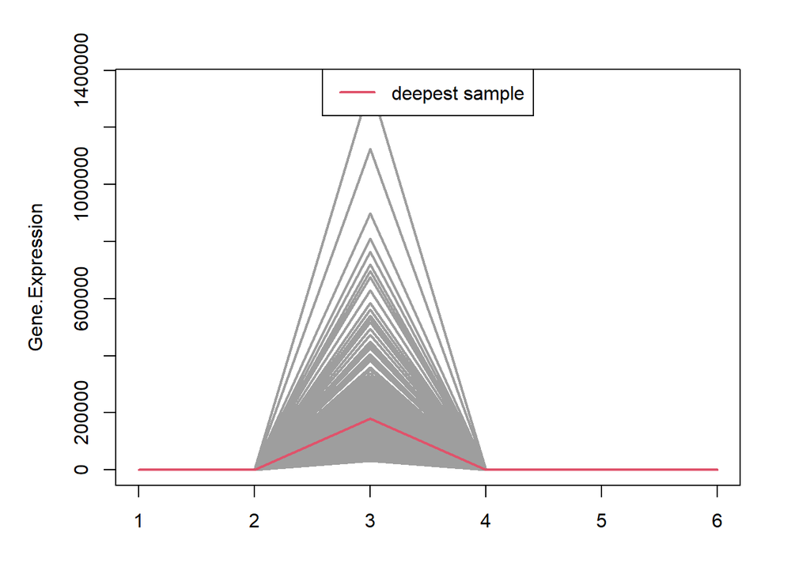

```
## $`Outlier Observations`
##      gender num_child ann_income education marital housing
## 1         0         0     427500         5       1       1
## 2         0         0     427500         5       1       1
## 78        1         0     247500         5       4       1
## 79        1         0     247500         5       4       1
## 80        1         0     247500         5       4       1
## 81        1         0     247500         5       4       1
## 217       1         0     255150         3       1       1
## 218       1         0     255150         3       1       1
## 219       1         0     255150         3       1       1
## 220       1         0     255150         3       1       1
## 221       1         0     255150         3       1       1
## 222       1         0     255150         3       1       1
## 250       1         0     270000         3       1       3
```

[output cut: 551 more lines]

```r
x<-newdata[,2:7]
depthout(x,cutoff=0.05)
```

With the threshold as 0.05, there are 493 outliers.

### 3. Deviation-based Approaches

#### a) Outlier detection using Mahalanobis Distance

```r
x<-newdata[,2:7]
maha(x,cutoff=0.9)
```

```
## $`Outlier Observations`
##      gender num_child ann_income education marital housing
## 1         0         0     427500         5       1       1
## 2         0         0     427500         5       1       1
## 28        0         3     270000         4       2       2
## 29        0         3     270000         4       2       2
## 77        1         0     315000         4       5       2
## 217       1         0     255150         3       1       1
## 218       1         0     255150         3       1       1
## 219       1         0     255150         3       1       1
## 220       1         0     255150         3       1       1
## 221       1         0     255150         3       1       1
## 222       1         0     255150         3       1       1
## 250       1         0     270000         3       1       3
## 251       1         0     270000         3       1       3
```

[output cut: 1623 more lines]

When the threshold is 0.9, there are 1,344 outliers.

#### b) Outlier detection using k Nearest Neighbours Distance method

```r
nn(x,k=4)
```

```
## $`Outlier Observations`
##      gender num_child ann_income education marital housing
## 1         0         0   427500.0         5       1       1
## 2         0         0   427500.0         5       1       1
## 8         1         0   283500.0         5       4       2
## 9         1         0   283500.0         5       4       2
## 10        1         0   283500.0         5       4       2
## 20        1         0   130500.0         3       2       2
## 21        1         0   130500.0         3       2       2
## 63        1         1   211500.0         4       1       2
## 64        1         1   211500.0         4       1       2
## 77        1         0   315000.0         4       5       2
## 223       1         2   157500.0         4       3       2
## 224       1         2   157500.0         4       3       2
## 240       1         0    94500.0         5       2       2
```

[output cut: 582 more lines]

When k is 4, there are 521 outliers.

#### c) Outlier detection using kth Nearest Neighbour Distance method

```r
nnk(x,k=4)
```

```
## $`Outlier Observations`
##      gender num_child ann_income education marital housing
## 1         0         0   427500.0         5       1       1
## 2         0         0   427500.0         5       1       1
## 8         1         0   283500.0         5       4       2
## 9         1         0   283500.0         5       4       2
## 10        1         0   283500.0         5       4       2
## 20        1         0   130500.0         3       2       2
## 21        1         0   130500.0         3       2       2
## 63        1         1   211500.0         4       1       2
## 64        1         1   211500.0         4       1       2
## 77        1         0   315000.0         4       5       2
## 223       1         2   157500.0         4       3       2
## 224       1         2   157500.0         4       3       2
## 240       1         0    94500.0         5       2       2
```

[output cut: 582 more lines]

When k is 4, there are 521 outliers.

### 5. Density-based Approaches

#### a) Outlier detection using Robust Kernal-based Outlier Factor(RKOF) algorithm

This method is not suitable for our data set, so we would not use it here.

#### b) Outlier detection using genralised dispersion

```r
x<-newdata[,2:7]
disp(x,cutoff=0.99)
```

```
## $`Outlier Observations`
##      gender num_child ann_income education marital housing
## 268       0         1     765000         5       2       2
## 269       0         1     765000         5       2       2
## 270       0         1     765000         5       2       2
## 271       0         1     765000         5       2       2
## 285       1         0     157500         5       4       4
## 286       1         0     157500         5       4       4
## 287       1         0     157500         5       4       4
## 288       1         0     157500         5       4       4
## 289       1         0     157500         5       4       4
## 290       1         0     157500         5       4       4
## 291       1         0     157500         5       4       4
## 292       1         0     157500         5       4       4
## 293       1         0     157500         5       4       4
```

[output cut: 547 more lines]

When the threshold is 0.99, there are 490 outliers.

### 6. Join assessment of outlier detection methods using techniques described under 2 to 5.

```r
x<-newdata[,2:7]
OutlierDetection(x)
```

```
## $`Outlier Observations`
##      gender num_child ann_income education marital housing
## 1         0         0     427500         5       1       1
## 2         0         0     427500         5       1       1
## 28        0         3     270000         4       2       2
## 29        0         3     270000         4       2       2
## 217       1         0     255150         3       1       1
## 218       1         0     255150         3       1       1
## 219       1         0     255150         3       1       1
## 220       1         0     255150         3       1       1
## 221       1         0     255150         3       1       1
## 222       1         0     255150         3       1       1
## 250       1         0     270000         3       1       3
## 251       1         0     270000         3       1       3
## 252       1         0     270000         3       1       3
```

[output cut: 1159 more lines]

```r
edit(OutlierDetection)
```

[output not shown]

[output cut: 21 more lines]

[output not shown]